# Week 6, networks

Ane Kleiven

2024-10-10

## Answers to questions **1. Given unlimited computational resources, how would you infer a Bayesian network from a gene expression table? Explain. Write at most 250 words.** Normally, the challenge in this task would be the enormous number of networks. Since I have unlimited computational resources, I don’t have to worry about this. I can just test all possible networks. To infer a Bayesian network from a gene expression table, you would have to find the posterior probability for all possible networks. After looking at all networks, you would look at the probability and choose the network with the highest probability. If I didn’t have unlimited computational resources, I would randomly start somewhere in the landscape of networks and move upwards to the highest probability. To ensure that there are no other networks with higher probability, I would have to repeat this process in other parts of the landscape – until the network with the highest probability is found. **2. A plant biologist is worried about how rising CO2 levels affect wheat production, and has therefore studied grain development at two different CO2 levels; A and B. He generated two transcriptomics datasets where gene expression is quantified across samples taken from multiple tissues and at different times using RNA-Seq. He then used these two datasets to infer two co-expression networks that describe expression similarities in conditions A and B, respectively. Looking at the networks he realizes that these are gigantic hairballs with thousands of nodes connected by millions of links. Hence it is not easy to identify the differences in co-expression between condition A and B. The biologist therefore comes to you. How would you analyze the data? Describe the method you would use and what type of results you would get by applying this method. Write at most 250 words.** The dataset is very complex, because the samples are from different tissues and at different times. The method that should be used is differential co-expression. Here the biologist must find the conserved co-expression genes (equal in both levels), specific co-expression genes (specific for one of the levels and differentiated co-expression genes (opposite co-expression in the two levels). The biologist can now make a list of the specific co-expression genes and the differentiated co-expression genes and identify genes important for CO2-levels. After grouping the different genes, he can make a network where the nodes and links are colored by group. The network will show different hubs, where for example some genes are differentially expressed with many other genes. The biologist can then go further into these hubs of genes and find genes or groups of genes that are important for CO2-levels. The goal is to find differences in relationships between genes.

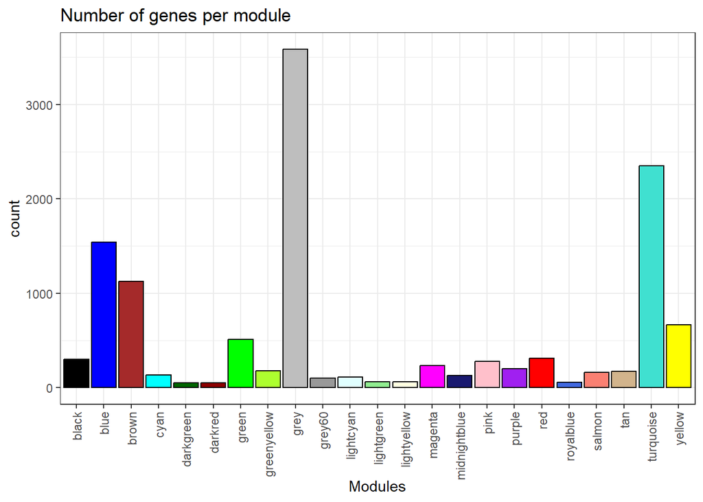

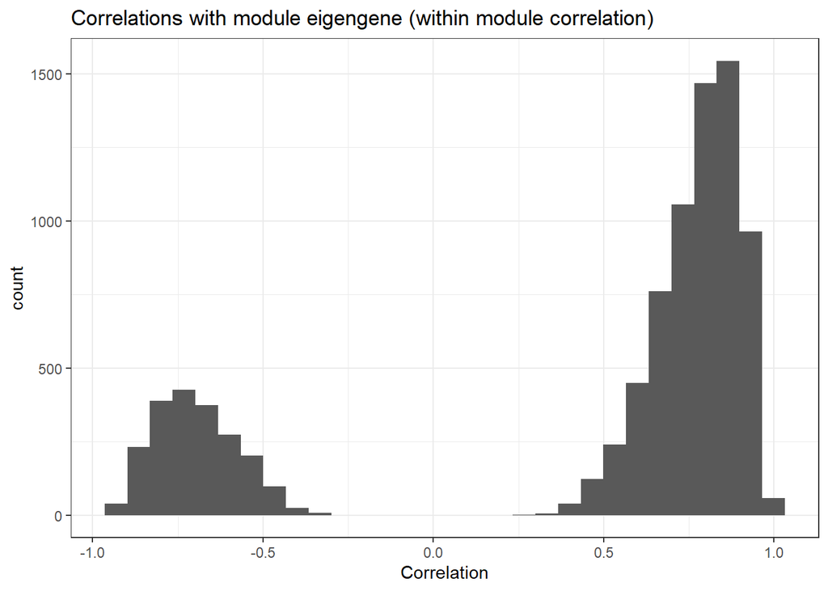

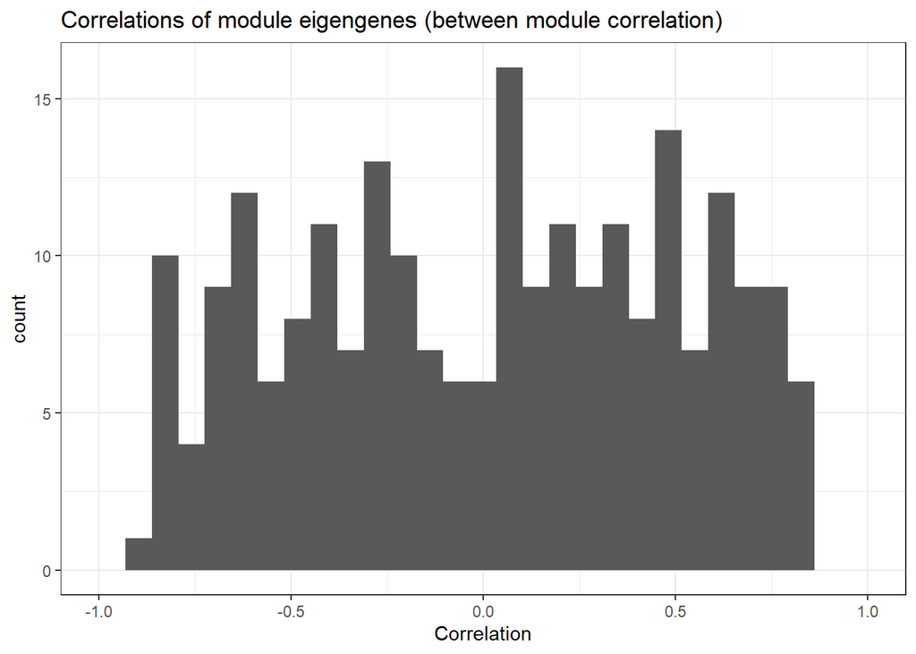

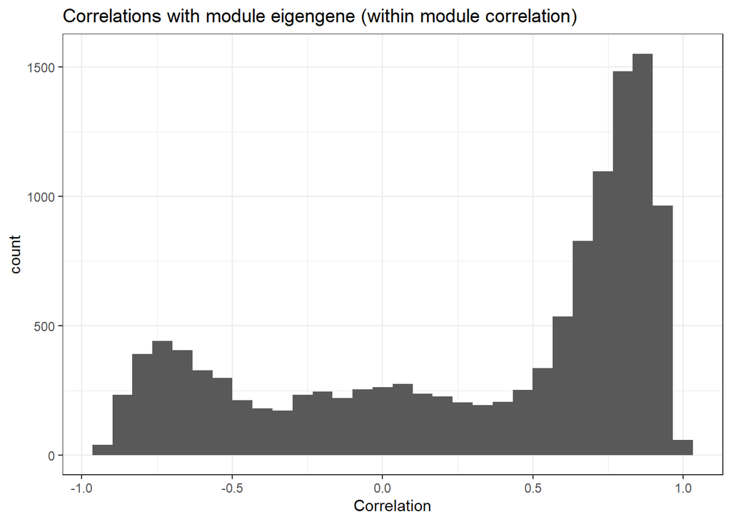

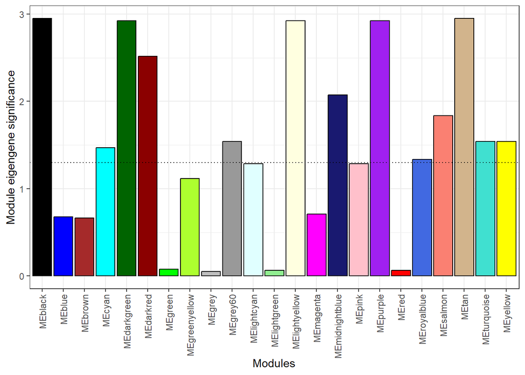

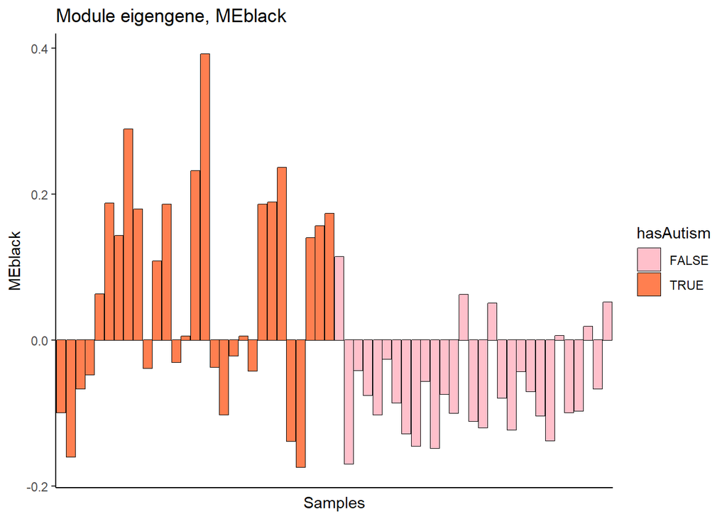

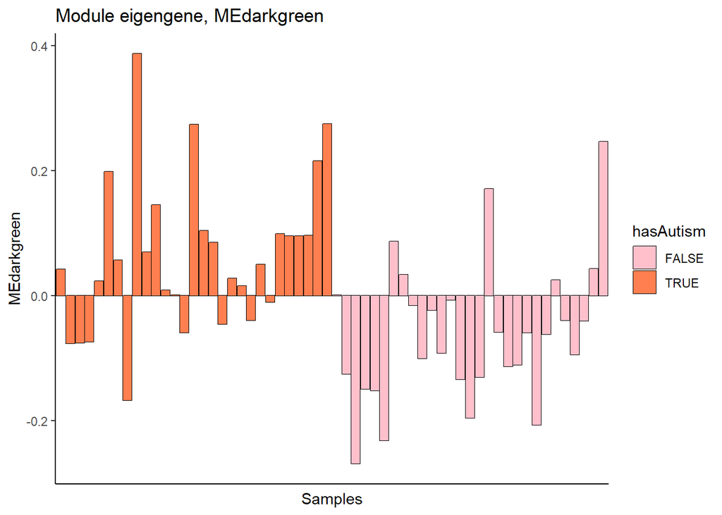

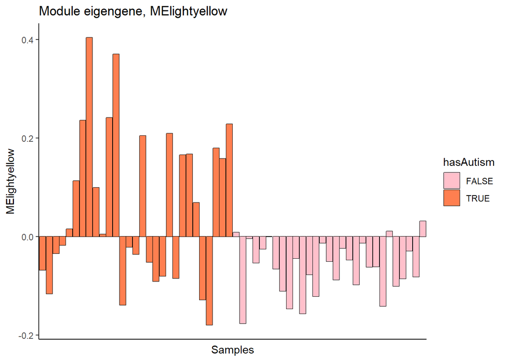

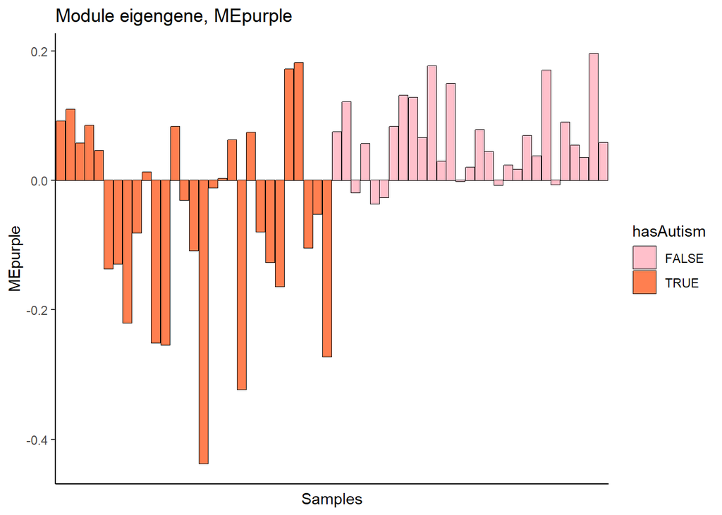

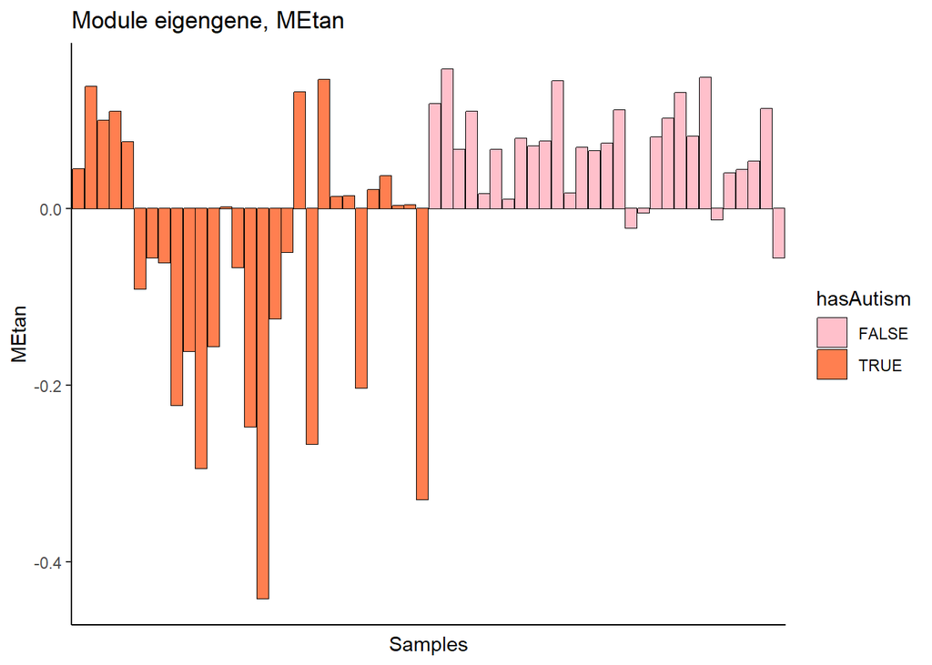